# Shopping Trends Analysis Report

Piotr Sikora

# Introduction

This report analyzes consumer shopping behavior patterns using a comprehensive dataset of retail transactions. The dataset contains information about customer demographics, purchasing preferences, and transaction details across multiple product categories.

**Objective:** To understand key patterns in consumer behavior, including purchase distributions across categories, demographic trends, seasonal variations, and relationships between customer characteristics and purchasing patterns.

**Dataset Overview:** The shopping trends dataset includes 3900 transactions with variables covering customer demographics (age, gender, location), purchase details (item, category, amount, season), customer engagement (review ratings, subscription status, previous purchases), and transaction characteristics (payment method, shipping type, discounts).

# Purchase Behavior Analysis

## Purchase Amounts by Category

[figure not shown]

The analysis reveals distinct patterns in purchase behavior across categories. Average purchase amount is pretty much equal among all categories. Clothing dominates in total volume, suggesting it’s the primary driver of revenue. Accessories and footwear show moderate performance, while outerwear appears less frequently in the dataset.

## Seasonal Purchase Patterns

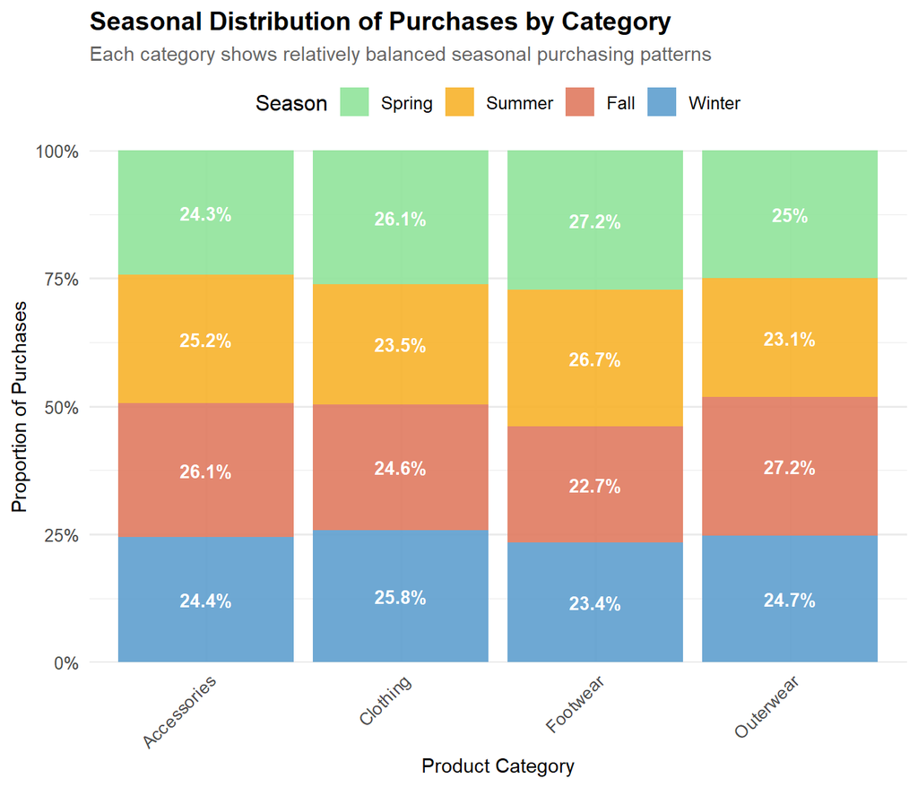

Seasonal purchasing shows remarkable balance across categories, with each season accounting for roughly 25% of purchases. This suggests consistent demand throughout the year rather than strong seasonal trends, which is valuable for inventory planning.

# Customer Demographics and Spending

## Age Distributions and Purchase Amounts by Gender

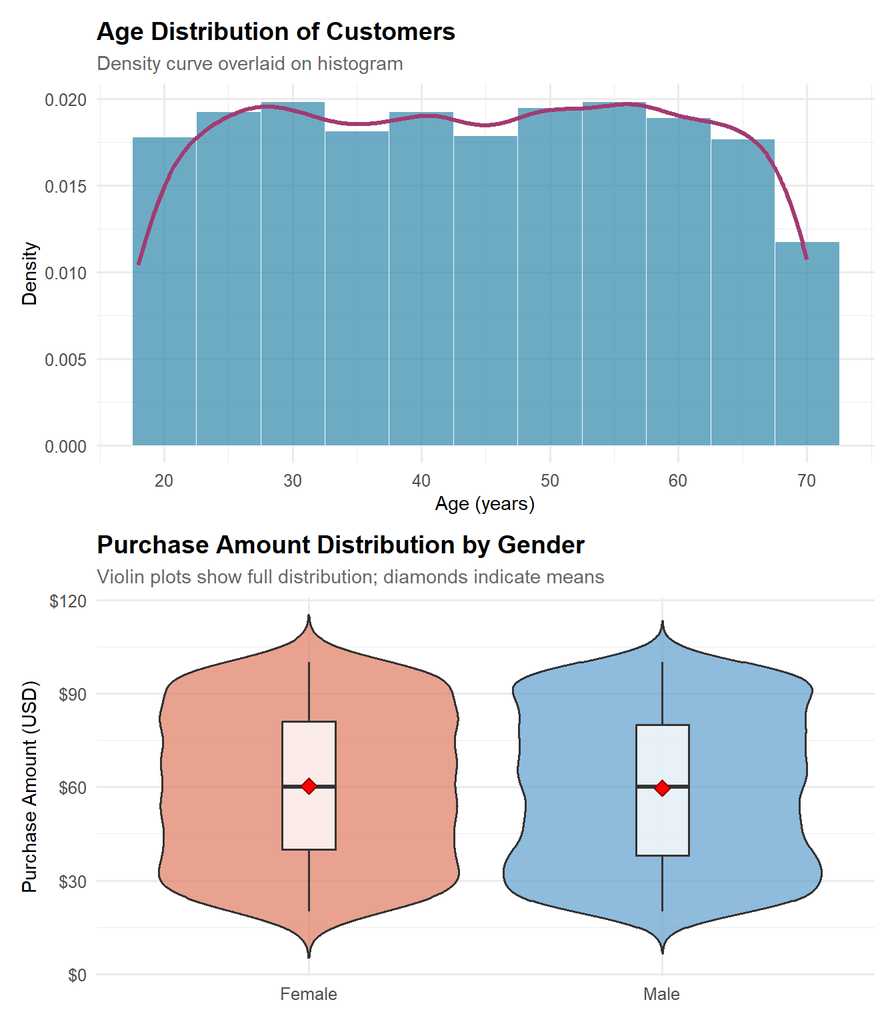

Customer ages follow a relatively uniform distribution across the 18-70 range, indicating broad market appeal. Purchase amounts show similar distributions between genders with comparable medians and spreads.

## Purchase Patterns by Age Group

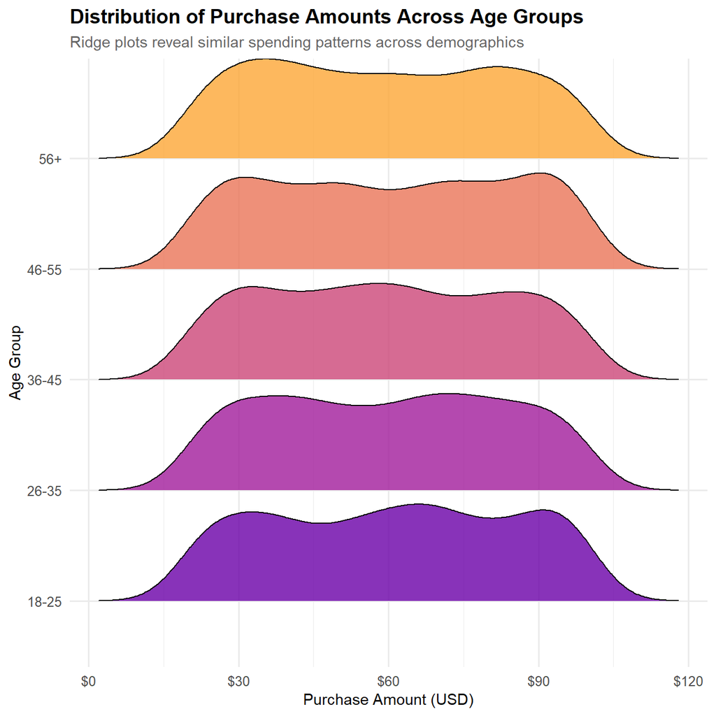

# Customer Engagement Patterns

## Subscription Status and Purchase Frequency

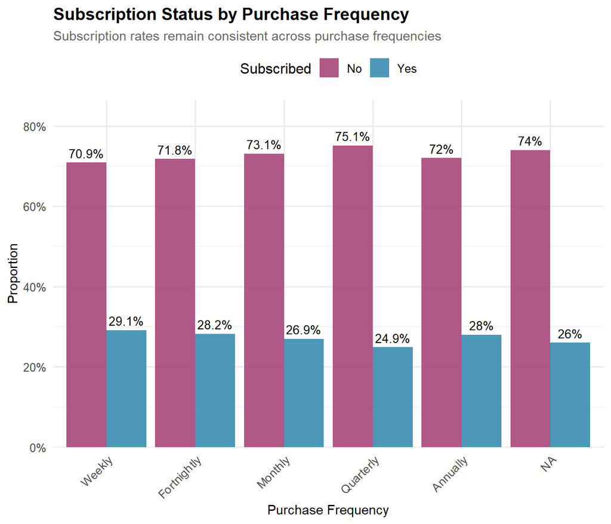

Subscription status shows remarkable consistency across all purchase frequencies, with both subscribed and non-subscribed customers distributed evenly. This suggests subscription benefits appeal equally to all customer segments rather than primarily targeting frequent shoppers.

## Review Ratings Distribution

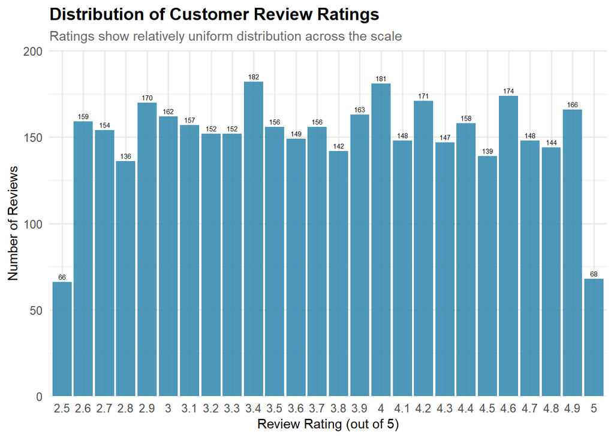

Review ratings follow a nearly uniform distribution across values between 2.5 and 5 stars, with each rating receiving roughly equal representation except at the endpoints (2.5 and 5). This unusual pattern suggests that while customers provide ratings across the full spectrum without strong skew toward positive or negative reviews, they are reluctant to give reviews below 2.5 stars.

# Discount and Promotion Analysis

## Impact of Discounts on Purchase Amounts

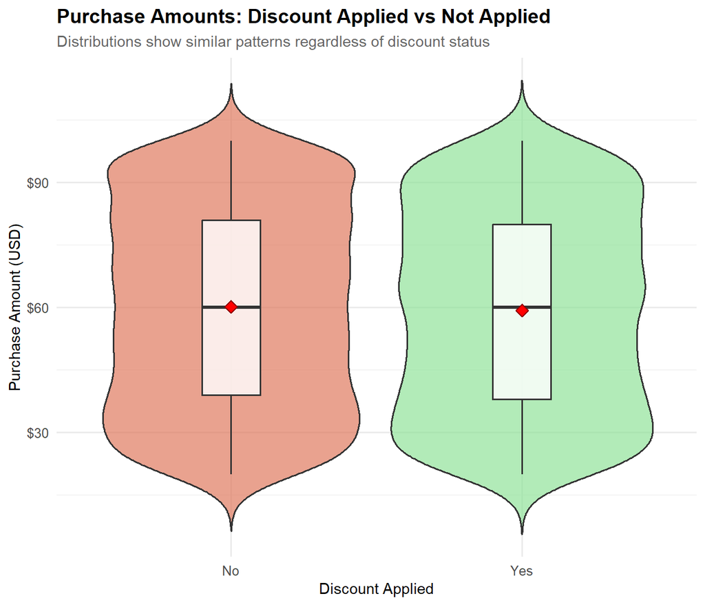

Purchase amounts show virtually identical distributions whether discounts were applied or not, with similar medians, quartiles, and spreads. This suggests that discount application may be randomized or that customers across all price points receive similar discount opportunities.

## Promotional Strategy Effectiveness

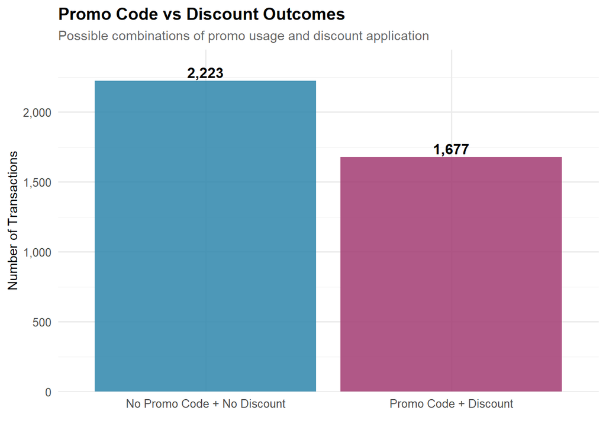

# Geographic and Payment Patterns

## Purchase Frequency by Location

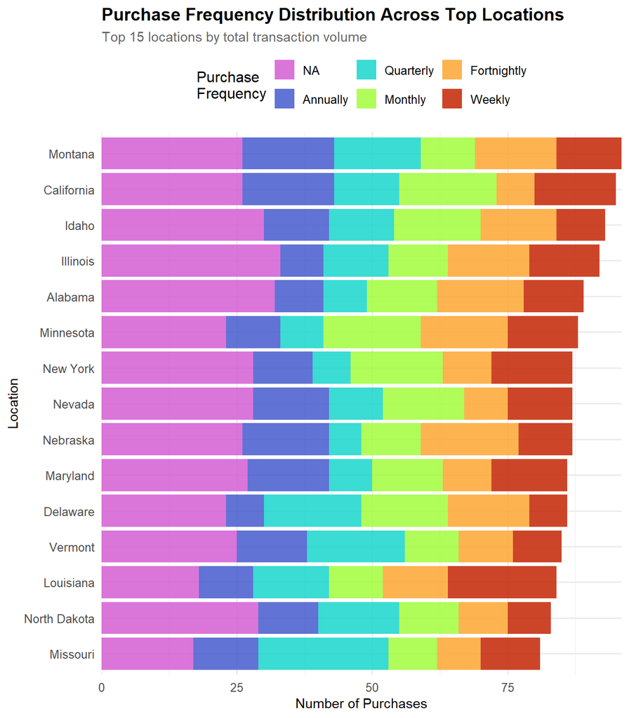

Geographic analysis of the top 15 locations reveals varied purchase patterns, with all frequency categories represented across locations. Montana shows the highest transaction volume in this sample, followed by California and Idaho. The distribution of purchase frequencies appears relatively consistent across locations with noteably Luisiana having most weakly users, Missouri having most quarterly users and Illinois having most users with unspecified shopping frequency.

## Payment Method Preferences

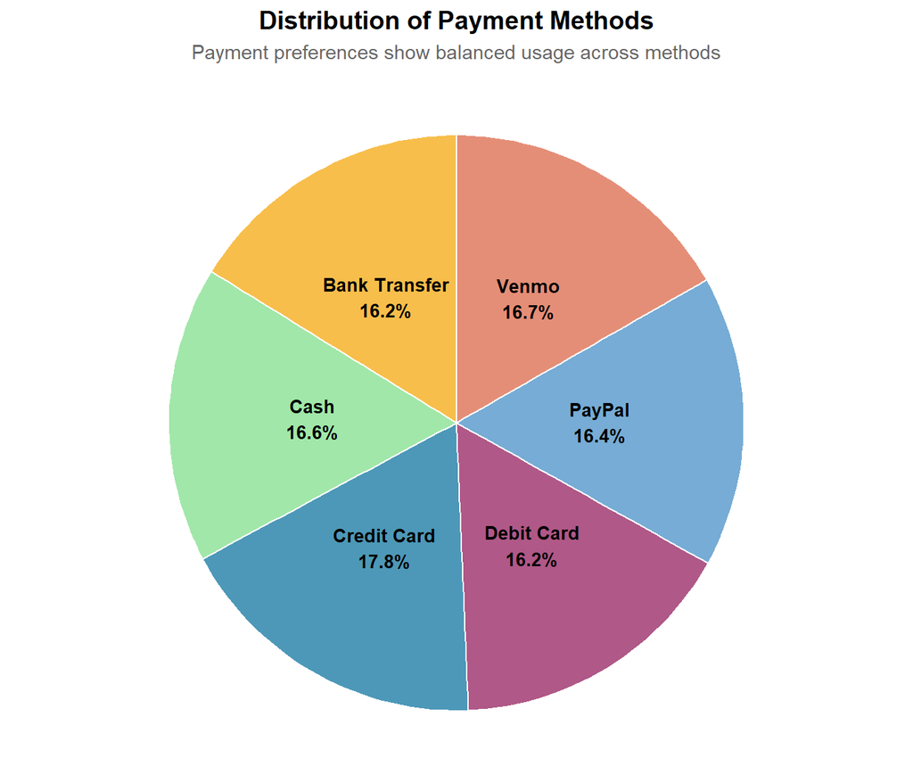

Payment method preferences are remarkably balanced across all available options, with each method capturing approximately 16-18% of transactions. This even distribution suggests customers have diverse payment preferences and the platform successfully accommodates multiple payment channels.

# Summary and Conclusions

This analysis of consumer shopping behavior reveals several key insights:

**Purchase Patterns:**

- Clothing dominates as the primary product category in volume
- Purchase amounts are consistent across age groups and genders, with typical transactions ranging $20-90
- Seasonal patterns show balanced distribution rather than strong seasonality

**Customer Engagement:**

- Subscription status is evenly distributed across purchase frequency categories
- Review ratings follow an unusual uniform distribution across rating levels between 2.5 and 5.
- Users are reluctant to give a very poor review - no reviews with rating below 2.5.
- Customer age distribution is broad (18-70 years), indicating wide market appeal

**Payment and Geography:**

- Payment methods show balanced usage across all options (credit/debit cards, digital wallets, cash)
- Geographic distribution shows concentration in specific states, with purchase frequency patterns varying by location

**Implications:**

The dataset reveals a remarkably balanced retail operation with consistent patterns across most dimensions. The lack of strong skews or correlations suggests either a well-diversified customer base or potentially synthetic data characteristics. For business strategy, the consistency across demographics supports maintaining broad product appeal, while the balanced seasonal patterns enable efficient year-round inventory management.

**Data Quality Note:** The unusual uniformity across many dimensions (ratings, seasonal patterns, discount impacts) may warrant investigation into data collection methods to ensure authentic customer behavior representation.